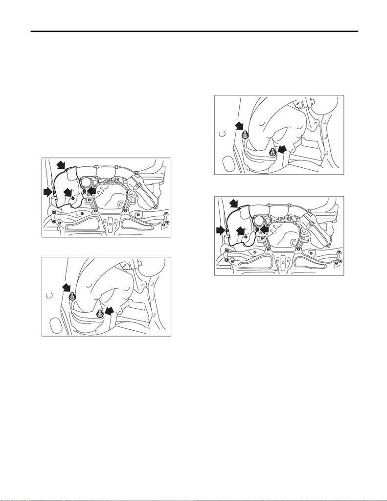

EX(STI)-11

Joint Pipe

EXHAUST

4. Joint Pipe

A: REMOVAL

CAUTION:

Vehicle components are extremely hot after

driving. Be wary of receiving burns from heated

parts.

1) Disconnect the ground cable from battery.

2) Lift up the vehicle.

3) Remove the under cover. <Ref. to EI-21, RE-

MOVAL, Front Under Cover.>

4) Remove the front oxygen (A/F) sensor. <Ref. to

FU(STI)-52, REMOVAL, Front Oxygen (A/F) Sen-

sor.>

5) Remove the exhaust manifold RH lower cover.

6) Remove the bolts and nuts which hold exhaust

manifold RH onto joint pipe.

7) Remove the center exhaust pipe. <Ref. to

EX(STI)-7, REMOVAL, Center Exhaust Pipe.>

8) Remove the turbocharger. <Ref. to IN(STI)-16,

REMOVAL, Turbocharger.>

9) Take off the joint pipe in the upward direction.

B: INSTALLATION

Install in the reverse order of removal.

NOTE:

Use a new gasket.

Tightening torque:

42.5 N·m (4.3 kgf-m, 31.3 ft-lb)

Tightening torque:

19 N·m (1.9 kgf-m, 14.0 ft-lb)

C: INSPECTION

1) Check the connections and welds for exhaust

leaks.

2) Make sure there are no holes or rusting.

EX-02260

EX-00018

EX-00018

EX-02260